# jquery Sparkline HTML Widget

ttmmghmmm

*(This blog was produced on: 2015-01-24.)*

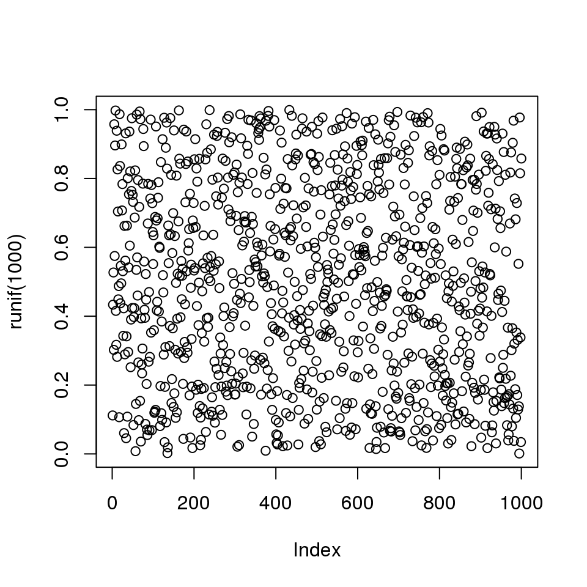

```r
plot(runif(1e3))
```

```
## stat_bin: binwidth defaulted to range/30. Use 'binwidth = x' to adjust this.
```

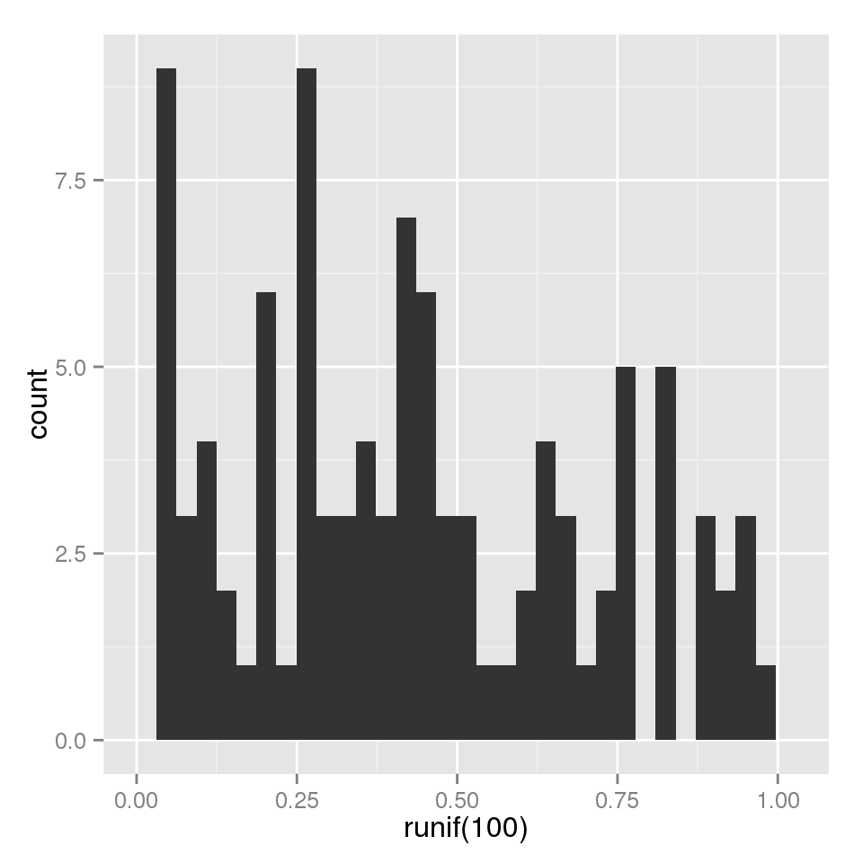

```r
library(ggplot2)
qplot(runif(1e2))
```

```r
library(htmlwidgets)
library(sparkline)
set.seed(1234)
x = rnorm(10)
y = rnorm(10)
```

Inline line graphs

[interactive chart not shown]

Bar charts

[interactive chart not shown]

negative values:

[interactive chart not shown]

| Stock | Sparkline | Boxplot |
| --- | --- | --- |
| x |  |  |
| y |  |  |

# Reproducibility

This final section highlights how this vignette was created.

## To recreate this vignette

Additional semantic markup can be added to the citations themselves, such as the reason for the citation. https://github.com/trinker/knitcitations

- `knitrBootstrap`
- Running behind the scenes:
  - `knitr` (Xie, 2014)
  - `rmarkdown` (Allaire, McPherson, Xie, Wickham, Cheng, and Allen, 2014)
  - Cite an R package using the ‘bibentry’ object (Temple Lang, 2014).

```r
# TODO: parse permalink? varialble
print(rmarkdown::metadata$yamlFileName) # permalink
docName <- rmarkdown::metadata$yamlFileName

## Create the vignette
library('knitrBootstrap')
knitrBootstrapFlag <- packageVersion('knitrBootstrap') < '1.0.0'
if(knitrBootstrapFlag) {
    ## CRAN version
    library('knitrBootstrap')
    cat("\n\n\tmetadata:title", rmarkdown::metadata$title, "\n\n")
    # TODO: stopifnot(file.exists(paste0(rmarkdown::metadata$title, ".Rmd")))
    print(system.time(knit_bootstrap(docName, chooser=c('boot', 'code'), show_code = TRUE)))
    # unlink('dots.md') # why remove .md file and in yaml?
} else {
    ## GitHub version
    library('rmarkdown')
    print(system.time(render(docName)))
}
unlink('citations.bib')
## Note: if you prefer the knitr version use:
# library('rmarkdown')
# system.time(render(docName, 'html_document'))

## Extract the R code
library('knitr')
knit(docName, tangle = TRUE)

KnitPost <- function(input, base.url = "/") {
    require(knitr)
    opts_knit$set(base.url = base.url)
    fig.path <- paste0("figs/", sub(".Rmd$", "", basename(input)), "/")
    opts_chunk$set(fig.path = fig.path)
    opts_chunk$set(fig.cap = "center")
    render_jekyll()
    knit(input, envir = parent.frame())
}
# TODO: insert the file name dynamically (both from _drafts and _posts?)
KnitPost(docName)
```

## YAML boiler plate

```r
str(rmarkdown::metadata) # https://github.com/rstudio/rmarkdown/issues/260
```

```
## List of 6
##  $ title       : chr "jquery Sparkline HTML Widget"
##  $ author      : chr "ttmmghmmm"
##  $ yamlFileName: chr "2015-01-19-htmlwidgetSparlines.Rmd"
##  $ tags        : chr "R sparkline"
##  $ categories  : chr "rstats sparkline htmkwidget"
##  $ output      :List of 2
##   ..$ html_document                     :List of 1
##   .. ..$ keep_md: logi FALSE
##   ..$ knitrBootstrap::bootstrap_document:List of 2
##   .. ..$ theme        : chr "Cyborg"
##   .. ..$ theme.chooser: logi TRUE
```

## `R` information

### Session and packages

```
## Session info-----------------------------------------------------------------------------
```

```
##  setting  value
##  version  R version 3.1.2 (2014-10-31)
##  system   x86_64, linux-gnu
##  ui       X11
##  language (EN)
##  collate  C
##  tz       <NA>
```

```
## Packages---------------------------------------------------------------------------------
```

```
##  package       * version  date       source
##  MASS            7.3.35   2014-09-30 CRAN (R 3.1.2)
##  RCurl           1.95.4.5 2014-12-28 CRAN (R 3.1.2)
##  RJSONIO         1.3.0    2014-07-28 CRAN (R 3.1.2)
##  Rcpp            0.11.3   2014-09-29 CRAN (R 3.1.2)
##  RefManageR      0.8.40   2014-10-29 CRAN (R 3.1.2)
##  XML             3.98.1.1 2013-06-20 CRAN (R 3.1.2)
##  bibtex          0.4.0    2014-12-31 CRAN (R 3.1.2)
##  bitops          1.0.6    2013-08-17 CRAN (R 3.1.2)
##  colorspace      1.2.4    2013-09-30 CRAN (R 3.1.2)
##  devtools      * 1.6.1    2014-10-07 CRAN (R 3.1.2)
##  digest          0.6.8    2014-12-31 CRAN (R 3.1.2)
##  evaluate        0.5.5    2014-04-29 CRAN (R 3.1.2)
##  formatR         1.0      2014-08-25 CRAN (R 3.1.2)
##  ggplot2       * 1.0.0.99 2015-01-18 Github (tdhock/ggplot2@aac38b6)
##  gtable          0.1.2    2012-12-05 CRAN (R 3.1.2)
##  htmltools       0.2.6    2014-09-08 CRAN (R 3.1.2)
##  htmlwidgets   * 0.3.2    2014-12-09 CRAN (R 3.1.2)
##  httr            0.6.1    2015-01-01 CRAN (R 3.1.2)
##  knitcitations * 1.0.5    2014-11-26 CRAN (R 3.1.2)
##  knitr         * 1.8.15   2015-01-11 local
##  labeling        0.3      2014-08-23 CRAN (R 3.1.2)
##  lubridate       1.3.3    2013-12-31 CRAN (R 3.1.2)
##  magrittr      * 1.5      2014-11-22 CRAN (R 3.1.2)
##  memoise         0.2.1    2014-04-22 CRAN (R 3.1.2)
##  munsell         0.4.2    2013-07-11 CRAN (R 3.1.2)
##  plyr            1.8.1    2014-02-26 CRAN (R 3.1.2)
##  proto           0.3.10   2012-12-22 CRAN (R 3.1.2)
##  reshape2        1.4.1    2014-12-06 CRAN (R 3.1.2)
##  rmarkdown       0.4.2    2015-01-11 Github (rstudio/rmarkdown@514d134)
##  rstudioapi      0.2      2014-12-31 CRAN (R 3.1.2)
##  scales          0.2.4    2014-04-22 CRAN (R 3.1.2)
##  sparkline     * 1.0      2015-01-10 Github (htmlwidgets/sparkline@aefe3a1)
##  stringr         0.6.2    2012-12-06 CRAN (R 3.1.2)
##  yaml            2.1.13   2014-06-12 CRAN (R 3.1.2)
```

### Runtime

Vignette generated in 4.7 seconds.

Timestamp 2015-01-24 19:08:11.

# Bibliography

Citations made with `knitcitations` (Boettiger, 2014).

[1] J. Allaire, J. McPherson, Y. Xie, et al. *rmarkdown: Dynamic Documents for R*. R package version 0.4.2. 2014. .

[2] C. Boettiger. *knitcitations: Citations for knitr markdown files*. R package version 1.0.5. 2014. .

[3] J. Hester. *knitrBootstrap: Knitr Bootstrap framework.* R package version 1.0.0. 2014. .

[4] D. Temple Lang. *RCurl: General network (HTTP/FTP/…) client interface for R*. R package version 1.95-4.5. 2014. .

[5] Y. Xie. “knitr: A Comprehensive Tool for Reproducible Research in R”. In: *Implementing Reproducible Computational Research*. Ed. by V. Stodden, F. Leisch and R. D. Peng. ISBN 978-1466561595. Chapman and Hall/CRC, 2014. .